# Project: Database_No_show_appointments Analysis

- Introduction
- Data Wrangling
- Exploratory Data Analysis
- Conclusions

## Introduction

### Dataset Description

This project will be analyzing the dataset which collects information from 100, 000 medical appointments in Brazil and is focused on the question of whether or not patients show up for their appointment. The dataset has the following characteristics:

- PatientId: Identifies a patient.
- AppointmentID: Identifies each appointment.
- Gender: Male or Female.
- ScheduledDay: Tells us on what day the patient set up his appointment.
- AppointmentDay: Tells us the day tht is given to the patient.
- Age: How old is the patient.
- Neighbourhood: Indicates the location of the hospital.
- Scholarship: Indicates whether or not the patient is enrolled in Brasilian welfare program.
- Hipertension: Indicates whether the patient is hypertensive or not.
- Diabetes: Indicates whether the patient is diabetic or not.
- Alcoholism: Indicates whether the patient takes alcohol or not.
- Handcap: Indicates whether the patient is handicap or not.
- SMS_received: One or more messages sent to the patient.
- No-show: Indicates whether the patient showed up for the appointment or not

Summarily for this analysis, there is one dependent variable (No-show) and thirteen independent variables (others as above)

### Note that:

No: Indicates that the patient showed up to his/her appointment

Yes: Indicates that the patient did not show up to his/her appointment

### Question(s) for Analysis

- What factors are important for us to know in order to predict if a patient will show up for their scheduled appointment?
- What percentage of the patients showed up for their appointments?
- What percentage of those who showed up for their appointments are male and what percentage are female?
- Does Age affect the patient attendance?
- What is the mean age of the patients who showed up for their appointments?
- What percentage of the patient received SMS?

```python
import numpy as np
import pandas as pd
import matplotlib.pyplot as plt
import seaborn as sns
%matplotlib inline
```

## Data Wrangling

```python
# Load your data and print out a few lines. Perform operations to inspect data
# types and look for instances of missing or possibly errant data.

df = pd.read_csv('noshowappointments-kagglev2-may-2016.csv')
df.head()
```

|  | PatientId | AppointmentID | Gender | ScheduledDay | AppointmentDay | Age | Neighbourhood | Scholarship | Hipertension | Diabetes | Alcoholism | Handcap | SMS_received | No-show |
| --- | --- | --- | --- | --- | --- | --- | --- | --- | --- | --- | --- | --- | --- | --- |
| 0 | 2.987250e+13 | 5642903 | F | 2016-04-29T18:38:08Z | 2016-04-29T00:00:00Z | 62 | JARDIM DA PENHA | 0 | 1 | 0 | 0 | 0 | 0 | No |
| 1 | 5.589978e+14 | 5642503 | M | 2016-04-29T16:08:27Z | 2016-04-29T00:00:00Z | 56 | JARDIM DA PENHA | 0 | 0 | 0 | 0 | 0 | 0 | No |
| 2 | 4.262962e+12 | 5642549 | F | 2016-04-29T16:19:04Z | 2016-04-29T00:00:00Z | 62 | MATA DA PRAIA | 0 | 0 | 0 | 0 | 0 | 0 | No |
| 3 | 8.679512e+11 | 5642828 | F | 2016-04-29T17:29:31Z | 2016-04-29T00:00:00Z | 8 | PONTAL DE CAMBURI | 0 | 0 | 0 | 0 | 0 | 0 | No |
| 4 | 8.841186e+12 | 5642494 | F | 2016-04-29T16:07:23Z | 2016-04-29T00:00:00Z | 56 | JARDIM DA PENHA | 0 | 1 | 1 | 0 | 0 | 0 | No |

Deduction: Some column names contain typographical error. Hence need to be renamed.

```python
# tells us the size of the dataset: (number of rows, number of columns)
df.shape
```

```
(110527, 14)
```

#### Check the statistical properties of all numerical variables.

```python
df.describe()
```

|  | PatientId | AppointmentID | Age | Scholarship | Hipertension | Diabetes | Alcoholism | Handcap | SMS_received |
| --- | --- | --- | --- | --- | --- | --- | --- | --- | --- |
| count | 1.105270e+05 | 1.105270e+05 | 110527.000000 | 110527.000000 | 110527.000000 | 110527.000000 | 110527.000000 | 110527.000000 | 110527.000000 |
| mean | 1.474963e+14 | 5.675305e+06 | 37.088874 | 0.098266 | 0.197246 | 0.071865 | 0.030400 | 0.022248 | 0.321026 |
| std | 2.560949e+14 | 7.129575e+04 | 23.110205 | 0.297675 | 0.397921 | 0.258265 | 0.171686 | 0.161543 | 0.466873 |
| min | 3.921784e+04 | 5.030230e+06 | -1.000000 | 0.000000 | 0.000000 | 0.000000 | 0.000000 | 0.000000 | 0.000000 |
| 25% | 4.172614e+12 | 5.640286e+06 | 18.000000 | 0.000000 | 0.000000 | 0.000000 | 0.000000 | 0.000000 | 0.000000 |
| 50% | 3.173184e+13 | 5.680573e+06 | 37.000000 | 0.000000 | 0.000000 | 0.000000 | 0.000000 | 0.000000 | 0.000000 |
| 75% | 9.439172e+13 | 5.725524e+06 | 55.000000 | 0.000000 | 0.000000 | 0.000000 | 0.000000 | 0.000000 | 1.000000 |
| max | 9.999816e+14 | 5.790484e+06 | 115.000000 | 1.000000 | 1.000000 | 1.000000 | 1.000000 | 4.000000 | 1.000000 |

Deduction: Age can never be -1. We can assume age 0 for babies less than 1 year. Therefore, record(s) with age -1 will be dropped.

#### info() shows the counts of Non-Null columns as well as the data type of each column.

```python
df.info()
```

```
<class 'pandas.core.frame.DataFrame'>
RangeIndex: 110527 entries, 0 to 110526
Data columns (total 14 columns):
 #   Column          Non-Null Count   Dtype
---  ------          --------------   -----
 0   PatientId       110527 non-null  float64
 1   AppointmentID   110527 non-null  int64
 2   Gender          110527 non-null  object
 3   ScheduledDay    110527 non-null  object
 4   AppointmentDay  110527 non-null  object
 5   Age             110527 non-null  int64
 6   Neighbourhood   110527 non-null  object
 7   Scholarship     110527 non-null  int64
 8   Hipertension    110527 non-null  int64
 9   Diabetes        110527 non-null  int64
 10  Alcoholism      110527 non-null  int64
 11  Handcap         110527 non-null  int64
 12  SMS_received    110527 non-null  int64
 13  No-show         110527 non-null  object
dtypes: float64(1), int64(8), object(5)
memory usage: 11.8+ MB
```

#### Deductions: No Null values. However, data type conversion is necessary for the following columns:

- PatientId : from float64 to int64
- ScheduledDay: from string to datetime and;
- AppointmentDay: from string to datetime

#### Checking for duplicates

```python
df.duplicated().sum()
```

```
0
```

Deduction: No duplicates

```python
# check for missing variable
df.isna().sum()
```

```
PatientId         0
AppointmentID     0
Gender            0
ScheduledDay      0
AppointmentDay    0
Age               0
Neighbourhood     0
Scholarship       0
Hipertension      0
Diabetes          0
Alcoholism        0
Handcap           0
SMS_received      0
No-show           0
dtype: int64
```

Deduction: No missing variable

### Data Cleaning

```python
# Renaming columns
df = df.rename(columns={'PatientId': 'PatientID', 'Hipertension': 'Hypertension', 'Handcap': 'Handicap', 'No-show': 'No_show'})
```

```python
# verify renaming
df.head(1)
```

|  | PatientID | AppointmentID | Gender | ScheduledDay | AppointmentDay | Age | Neighbourhood | Scholarship | Hypertension | Diabetes | Alcoholism | Handicap | SMS_received | No_show |
| --- | --- | --- | --- | --- | --- | --- | --- | --- | --- | --- | --- | --- | --- | --- |
| 0 | 2.987250e+13 | 5642903 | F | 2016-04-29T18:38:08Z | 2016-04-29T00:00:00Z | 62 | JARDIM DA PENHA | 0 | 1 | 0 | 0 | 0 | 0 | No |

```python
# verify the record where age=1 was dropped
df = df[df.Age >= 0]
df.shape
```

```
(110526, 14)
```

##### Fixing the Data Types issues.

```python
# Converting the PatientId column from float64 to int64
df['PatientID'] = df['PatientID'].astype('int64')
```

```python
# Converting ScheduledDay column from string to datetime
df['ScheduledDay'] = pd.to_datetime(df['ScheduledDay'])
```

```python
# Converting AppointmentDay column from string to datetime
df['AppointmentDay'] = pd.to_datetime(df['AppointmentDay'])
# df.info()
```

```python
# A function that returns the unique count of values in each columns of the DataFrame
def print_unique_values(df):
        df_cols = df.columns
        for col in df_cols:
            print(f"Unique Values in {col} => {df[col].unique()}")
```

```python
# invoking the function
print_unique_values(df)
```

```
Unique Values in PatientID => [ 29872499824296 558997776694438   4262962299951 ...  72633149253362
 996997666245785  15576631729893]
Unique Values in AppointmentID => [5642903 5642503 5642549 ... 5630692 5630323 5629448]
Unique Values in Gender => ['F' 'M']
Unique Values in ScheduledDay => <DatetimeArray>
['2016-04-29 18:38:08+00:00', '2016-04-29 16:08:27+00:00',
 '2016-04-29 16:19:04+00:00', '2016-04-29 17:29:31+00:00',
 '2016-04-29 16:07:23+00:00', '2016-04-27 08:36:51+00:00',
 '2016-04-27 15:05:12+00:00', '2016-04-27 15:39:58+00:00',
 '2016-04-29 08:02:16+00:00', '2016-04-27 12:48:25+00:00',
 ...
 '2016-06-07 07:45:16+00:00', '2016-06-07 07:38:34+00:00',
 '2016-04-27 15:15:06+00:00', '2016-05-03 07:51:47+00:00',
 '2016-05-03 08:23:40+00:00', '2016-05-03 09:15:35+00:00',
 '2016-05-03 07:27:33+00:00', '2016-04-27 16:03:52+00:00',
 '2016-04-27 15:09:23+00:00', '2016-04-27 13:30:56+00:00']
Length: 103548, dtype: datetime64[ns, UTC]
Unique Values in AppointmentDay => <DatetimeArray>
['2016-04-29 00:00:00+00:00', '2016-05-03 00:00:00+00:00',
 '2016-05-10 00:00:00+00:00', '2016-05-17 00:00:00+00:00',
 '2016-05-24 00:00:00+00:00', '2016-05-31 00:00:00+00:00',
 '2016-05-02 00:00:00+00:00', '2016-05-30 00:00:00+00:00',
 '2016-05-16 00:00:00+00:00', '2016-05-04 00:00:00+00:00',
 '2016-05-19 00:00:00+00:00', '2016-05-12 00:00:00+00:00',
 '2016-05-06 00:00:00+00:00', '2016-05-20 00:00:00+00:00',
 '2016-05-05 00:00:00+00:00', '2016-05-13 00:00:00+00:00',
 '2016-05-09 00:00:00+00:00', '2016-05-25 00:00:00+00:00',
 '2016-05-11 00:00:00+00:00', '2016-05-18 00:00:00+00:00',
 '2016-05-14 00:00:00+00:00', '2016-06-02 00:00:00+00:00',
 '2016-06-03 00:00:00+00:00', '2016-06-06 00:00:00+00:00',
 '2016-06-07 00:00:00+00:00', '2016-06-01 00:00:00+00:00',
 '2016-06-08 00:00:00+00:00']
Length: 27, dtype: datetime64[ns, UTC]
Unique Values in Age => [ 62  56   8  76  23  39  21  19  30  29  22  28  54  15  50  40  46   4
  13  65  45  51  32  12  61  38  79  18  63  64  85  59  55  71  49  78
  31  58  27   6   2  11   7   0   3   1  69  68  60  67  36  10  35  20
  26  34  33  16  42   5  47  17  41  44  37  24  66  77  81  70  53  75
  73  52  74  43  89  57  14   9  48  83  72  25  80  87  88  84  82  90
  94  86  91  98  92  96  93  95  97 102 115 100  99]
Unique Values in Neighbourhood => ['JARDIM DA PENHA' 'MATA DA PRAIA' 'PONTAL DE CAMBURI' 'REPÚBLICA'
```

[output cut: 9 more lines]

```
 'ILHA DO FRADE' 'GURIGICA' 'JOANA D´ARC' 'CONSOLAÇÃO' 'PRAIA DO CANTO'
 'BOA VISTA' 'MORADA DE CAMBURI' 'SANTA LUÍZA' 'SANTA LÚCIA'
 'BARRO VERMELHO' 'ESTRELINHA' 'FORTE SÃO JOÃO' 'FONTE GRANDE'
 'ENSEADA DO SUÁ' 'SANTOS REIS' 'PIEDADE' 'JESUS DE NAZARETH'
 'SANTA TEREZA' 'CRUZAMENTO' 'ILHA DO PRÍNCIPE' 'ROMÃO' 'COMDUSA'
 'SANTA CECÍLIA' 'VILA RUBIM' 'DE LOURDES' 'DO QUADRO' 'DO CABRAL' 'HORTO'
 'SEGURANÇA DO LAR' 'ILHA DO BOI' 'FRADINHOS' 'NAZARETH' 'AEROPORTO'
 'ILHAS OCEÂNICAS DE TRINDADE' 'PARQUE INDUSTRIAL']
Unique Values in Scholarship => [0 1]
Unique Values in Hypertension => [1 0]
Unique Values in Diabetes => [0 1]
Unique Values in Alcoholism => [0 1]
Unique Values in Handicap => [0 1 2 3 4]
Unique Values in SMS_received => [0 1]
Unique Values in No_show => ['No' 'Yes']
```

## Exploratory Data Analysis

### Research Question 1: What factors are important for us to know in order to predict if a patient will show up for their scheduled appointment?

```python
# Use this, and more code cells, to explore your data. Don't forget to add
#   Markdown cells to document your observations and findings.
```

```python
# make a copy of the DataFrame and name it df_correlation. This is to be used to investigate the relationships
# between the dependent and independent variables
df_correlation = df.copy()
```

```python
# Turning the value of the No_show column into a numerical values.
df_correlation['No_show'] = df_correlation['No_show'].map({'Yes': 1, 'No': 0})
```

```python
# Investigating the relationships
df_correlation.corr()
```

|  | PatientID | AppointmentID | Age | Scholarship | Hypertension | Diabetes | Alcoholism | Handicap | SMS_received | No_show |
| --- | --- | --- | --- | --- | --- | --- | --- | --- | --- | --- |
| PatientID | 1.000000 | 0.004023 | -0.004121 | -0.002877 | -0.006436 | 0.001608 | 0.011014 | -0.007915 | -0.009742 | -0.001456 |
| AppointmentID | 0.004023 | 1.000000 | -0.019106 | 0.022619 | 0.012759 | 0.022632 | 0.032946 | 0.014107 | -0.256613 | -0.162597 |
| Age | -0.004121 | -0.019106 | 1.000000 | -0.092463 | 0.504586 | 0.292391 | 0.095810 | 0.078032 | 0.012633 | -0.060327 |
| Scholarship | -0.002877 | 0.022619 | -0.092463 | 1.000000 | -0.019730 | -0.024894 | 0.035022 | -0.008587 | 0.001192 | 0.029134 |
| Hypertension | -0.006436 | 0.012759 | 0.504586 | -0.019730 | 1.000000 | 0.433085 | 0.087970 | 0.080083 | -0.006270 | -0.035704 |
| Diabetes | 0.001608 | 0.022632 | 0.292391 | -0.024894 | 0.433085 | 1.000000 | 0.018473 | 0.057530 | -0.014552 | -0.015181 |
| Alcoholism | 0.011014 | 0.032946 | 0.095810 | 0.035022 | 0.087970 | 0.018473 | 1.000000 | 0.004647 | -0.026149 | -0.000197 |
| Handicap | -0.007915 | 0.014107 | 0.078032 | -0.008587 | 0.080083 | 0.057530 | 0.004647 | 1.000000 | -0.024162 | -0.006077 |
| SMS_received | -0.009742 | -0.256613 | 0.012633 | 0.001192 | -0.006270 | -0.014552 | -0.026149 | -0.024162 | 1.000000 | 0.126428 |
| No_show | -0.001456 | -0.162597 | -0.060327 | 0.029134 | -0.035704 | -0.015181 | -0.000197 | -0.006077 | 0.126428 | 1.000000 |

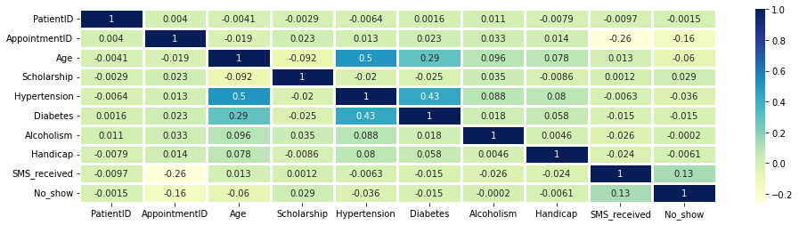

```python
# plotting correlation heatmap
plt.figure(figsize=(16,4))
dataplot = sns.heatmap(df_correlation.corr(), cmap="YlGnBu", annot=True, linewidths=3);
```

##### There is a weak positive correlation between No_show and SMS_received, but a weak negative correlation between No_show and AppointmentID

Deduction: To predict if a patient will show up for their scheduled appointment, it is important to know the following:

- Whether the patient gets SMS as a reminder or not.
- How early is the appointment given to the patient, as some patients tend to even forget that they have an appointment if far.

### Research Question 2: What percentage of the patients showed up for their appointments?

```python
# calculation the percentage of the patients showed up for their appointments
df['No_show'].value_counts()/df['No_show'].shape[0] * 100
```

```
No     79.806561
Yes    20.193439
Name: No_show, dtype: float64
```

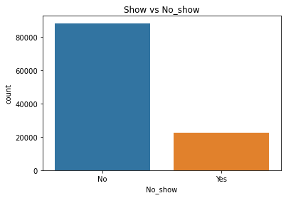

```python
# visualizing using seaborn
ax = sns.countplot(x=df['No_show'], data=df)
ax.set_title("Show vs No_show");
```

About 79.8% of the patients showed up for their appoint but 20.1% of them didn't.

### Research Question 3: What percentage of those who showed up for their appointments are male and what percentage are female?

```python
# Calculating the percentages based on Gender
df.groupby('Gender')['No_show'].value_counts()
```

```
Gender  No_show
F       No         57245
        Yes        14594
M       No         30962
        Yes         7725
Name: No_show, dtype: int64
```

```python
# male
percentage_of_male = df.groupby('Gender')['No_show'].value_counts()[2]/df['No_show'].value_counts()['No'] * 100
percentage_of_male
```

```
35.101522554899276
```

```python
# female
percentage_of_female = df.groupby('Gender')['No_show'].value_counts()[0]/df['No_show'].value_counts()['No'] * 100
percentage_of_female
```

```
64.89847744510074
```

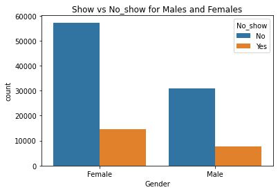

```python
ax = sns.countplot(x=df['Gender'], data=df, hue=df['No_show'])
ax.set_title("Show vs No_show for Males and Females");
x_ticks_labels = ['Female', 'Male']
ax.set_xticklabels(x_ticks_labels);
```

About 35.1% of those who showed up for their appointment were males while 64.8% were females. That more females showed up.

### Research Question 4: Does Age affect the patient attendance?

```python
# sorting unique values of the Age column
np.sort(df['Age'].unique())
```

```
array([  0,   1,   2,   3,   4,   5,   6,   7,   8,   9,  10,  11,  12,
        13,  14,  15,  16,  17,  18,  19,  20,  21,  22,  23,  24,  25,
        26,  27,  28,  29,  30,  31,  32,  33,  34,  35,  36,  37,  38,
        39,  40,  41,  42,  43,  44,  45,  46,  47,  48,  49,  50,  51,
        52,  53,  54,  55,  56,  57,  58,  59,  60,  61,  62,  63,  64,
        65,  66,  67,  68,  69,  70,  71,  72,  73,  74,  75,  76,  77,
        78,  79,  80,  81,  82,  83,  84,  85,  86,  87,  88,  89,  90,
        91,  92,  93,  94,  95,  96,  97,  98,  99, 100, 102, 115],
      dtype=int64)
```

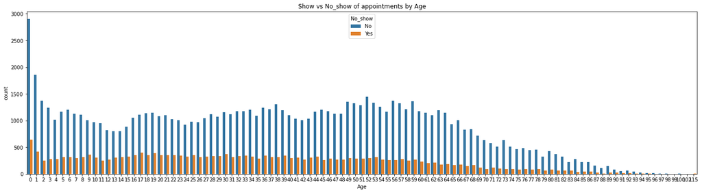

```python
# visualization
plt.figure(figsize=(24,6))
ax = sns.countplot(x=df['Age'], hue=df['No_show']);
ax.set_title("Show vs No_show of appointments by Age");
```

Age does not really affects the attendance because at varying age, a change in attendance was not really visible.

### Research Question 5: What is the mean age of the patients who showed up for their appointments?

```python
# mean age of patients according to attendance
df.groupby('No_show')['Age'].mean()
```

```
No_show
No     37.790504
Yes    34.317667
Name: Age, dtype: float64
```

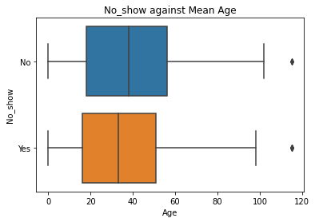

```python
# Visualization
ax = sns.boxplot(x=df.Age, y=df.No_show );
ax.set_title("No_show against Mean Age");
```

The mean age of patients who showed up for their appointment is 37.7 and this is close to that of those who did not showed up

### Research Question 6: What percentage of the patient received SMS?

```python
# percentage of patients who received SMS
df.query('SMS_received == 1')['SMS_received'].count()/df['SMS_received'].count() * 100
```

```
32.10285362720084
```

```python
# Number of patients who received and those who didn't
df['SMS_received'].value_counts()
```

```
0    75044
1    35482
Name: SMS_received, dtype: int64
```

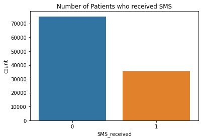

```python
# visualization
ax = sns.countplot(x='SMS_received', data=df);
ax.set_title("Number of Patients who received SMS");
```

Only about 32% of the patients received SMS as reminder.

## Conclusions

. It may be good to know whether the patients received SMS and how how early the scheduledDay comes to predict if they would show up for their appointments

. About 79.8% of the patients showed up for their appoint but 20.1% of them didn't.

. About 35.1% of those who showed up for their appointment were males while 64.8% were females. That more females showed up.

. Age does not really affects the attendance because at varying age, a change in attendance was not really visible.

. The mean age of patients who showed up for their appointment is 37.7 and this is close to that of those who did not showed up.

. Only about 32% of the patients received SMS as reminder.

## Limitations

. The above conclusions are based on my understanding of the dataset, therefore, it should be taken as tentative.

. Statistical tests such as anova, t-test, f-test might be required for final conclusion.

```python
from subprocess import call
call(['python', '-m', 'nbconvert', 'Investigate_a_Dataset.ipynb'])
```